# Améliorer les cartes des maladies avec des étiquettes en R

## 10.1 Pratique 2 : Créer une carte choroplèthe montrant les taux d’augmentation du paludisme avec les étiquettes des États

**Instructions**

1. Préparer le tracé de base avec le jeu de données `malaria3`.
2. La couleur de remplissage représente le taux d’augmentation de 2015 à 2021.
3. Étiqueter chaque État avec son nom.
4. Personnaliser l’échelle de couleur et ajouter des titres.

```r
# Combinaison de la visualisation des taux d'augmentation avec les noms des États
ggplot(data = malaria3) +
  _______ +  # Remplissez le code pour générer la carte choroplèthe
  _______ +  # Ajoutez les noms des États à chaque région
  _______ +  # Spécifiez l'échelle de couleurs pour les taux d'augmentation
  _______    # Ajoutez des titres et des étiquette
```

[output not shown]

# 11 Mettre en évidence une région spécifique sur la carte tout en préservant le contexte

‣ Mettre l’accent sur une zone particulière (par exemple, la région de “Kano”) sur la carte.

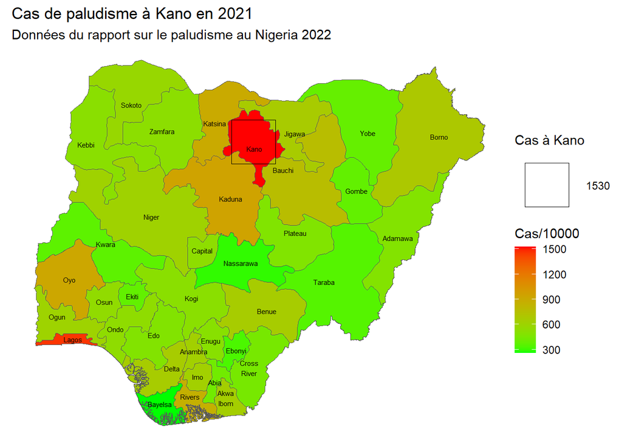

```r
# Visualiser les cas de paludisme à travers le Nigeria en mettant l'accent sur Kano
ggplot(data = malaria3) +
  # Créer une carte choroplèthe avec une couleur basée sur les cas de paludisme en 2021
  geom_sf(aes(fill = cases_2021/10000)) +
  # Définir un gradient de couleur continu du vert au rouge
  scale_fill_continuous(low = "green", high = "red")+
  # Étiqueter chaque région avec son nom
  geom_sf_text(aes(label = str_wrap(state_name, 1)), size = 2)+

  # Superposer un carré sur Kano pour le mettre en évidence
  geom_point(data = subset(malaria3, state_name == "Kano"),
             aes(x = st_coordinates(st_centroid(geometry))[1],
                 y = st_coordinates(st_centroid(geometry))[2], size = round(cases_2021/10000)),
             color = "black", shape = 22,  fill = "transparent") +

  scale_size_continuous(range = c(15, 20))+

  # Ajouter un titre et des légendes
  labs(title = "Cas de paludisme à Kano en 2021", subtitle = "Données du rapport sur le paludisme au Nigeria 2022", size = "Cas à Kano", fill = "Cas/10000",)+

  # Appliquer un thème minimal pour la clarté
  theme_void()
```

# 12 Étiqueter les emplacements des points : Explorer le taux de positivité et l’incidence du paludisme

‣ Cartographier des points de données spécifiques (par exemple, des tests de paludisme) pour des aperçus plus profonds.

```r
# Récupération des données
nigeria_pr <- malariaAtlas::getPR(ISO = "NGA", species = "both")

nigeria_pr %>%
  filter(!is.na(pr))%>%
  drop_na(longitude, latitude) %>%
  st_as_sf(coords = c("longitude", "latitude"), crs = 4326) -> nigeria_pr
```

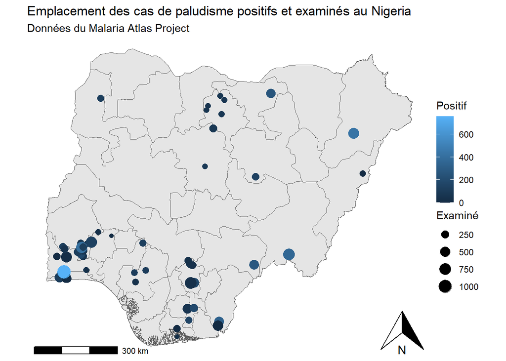

```r
ggplot()+
  geom_sf(data = nga_adm1)+
  geom_sf(aes(size = examined, color = positive), data = nigeria_pr)+
  labs(title = "Emplacement des cas de paludisme positifs et examinés au Nigeria",
       subtitle = "Données du Malaria Atlas Project",
       color = "Positif",
       size = "Examiné")+
  ylab("Longitude")+
  xlab("Latitude")+
  ggspatial::annotation_north_arrow(location = "br")+
  ggspatial::annotation_scale(location = "bl")+
  theme_void()
```

## 12.1 Pratique 3 : Visualiser le taux de positivité par taille et couleur

**Instructions**

- Représenter le taux de positivité pour chaque emplacement.
- Modifier la taille des points pour refléter le taux de positivité.

```r
# Visualiser le taux de positivité
ggplot() +
  _________ +
  _________ +
  _________ +
  _________
```

# 13 RECAPITULATIF !

En complétant cette leçon, vous devriez être capable de :

‣ Utiliser des annotations et des étiquettes pour des données spatiales complexes.

‣ Montrer une compétence dans l’intégration d’indicateurs continus et le superposition d’étiquettes sur des cartes.

‣ Mettre en évidence des zones tout en préservant le contexte géographique plus large.

‣ Utiliser {ggplot2}, {sf} et {ggspatial} pour une cartographie avancée.